# Linear Regression

#### Defination :

==> Linear regression is a linear approach to modeling the relationship between a scalar response (or dependent variable) and one or more explanatory variables (or independent variables). The case of one explanatory variable is called simple linear regression.

==> Simple linear regression is useful for finding relationship between two continuous variables. One is predictor or independent variable and other is response or dependent variable.

==> Linear regression has been applied to many important scientific and social problems.

==> Regression models help investigating bivariate and multivariate relationships between variables, where we can hypothesize that 1 variable depends on another variable or a combination of other variables.

==> Regression analysis enables to find average relationship.

### Simple Linear Regression

==> Linear relationship between x (explanatory variable) and y (dependent variable).

==> Epsilon describes the random component of the linear relationship between x and y.

$$ \huge y_i = \alpha + \beta * x_i + \epsilon $$

==> Here $ y_i $ is the dependent value. that depent on variable $ x $.

**A simple example:**

• x has 10 observations: 0,1,2,3,4,5,6,7,8,9

• The true relationship between y and x is: y=5+1*x, thus, the true y takes on the values: 5,6,7,8,9,10,11,12,13,14

• There is some disturbance e.g. a measurement error, which is standard normally distributed: thus the y we can measure takes on the values: 6.95,5.22,6.36,7.03,9.71,9.67,10.69,13.85, 13.21,14.82 – which are close to the true values, but for any given observation the observed values are a little larger or smaller than the true values.

• the relationship between x and y should hold on average true but is not exact

• When we do our analysis, we don‘t know the true relationship and the true y, we just have the observed x and y.

• We know that the relationship between x and y should have the following form: y=alpha+beta*x+epsilon (we hypothesize a linear relationship)

• The regression analysis „estimates“ the parameters alpha and beta by using the given observations for x and y.

• The simplest form of estimating alpha and beta is called **least squares regression**

• Minimize the sum of all squared deviations from the line (squared residuals)

• This is done mathematically by the statistical program at hand

• The values of the dependent variable (values on the line) are called predicted values of the regression (yhat): 4.97,6.03,7.10,8.16,9.22, 10.28,11.34,12.41,13.47,14.53 – these are very close to the **true values**.

==> The estimated alpha = 4.97 and beta = 1.06

==> **Least squares regression: minimizes the squared residuals**

#### ==> Derivation of the OLS-Parameters alpha and beta.

#### ==> The relationship between x and y is described by the function

#### ==> The difference between the dependent variable y and the estimated systematic influence of x on y is named the residual.

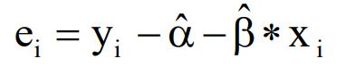

#### ==> The optimal estimates for alpha and beta we need a choice-criterion, in the case of LS this criterion is the sum of squared residuals: we calculate alpha and beta for the case in which the sum of all squared deviations (residuals) is minimal

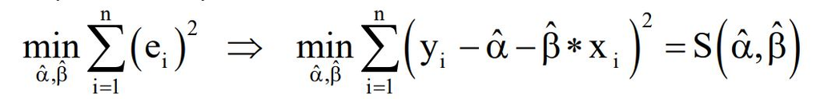

#### ==> Minimizing the function requires to calculate the first order Derivation with respect to alpha and beta and set them zero.

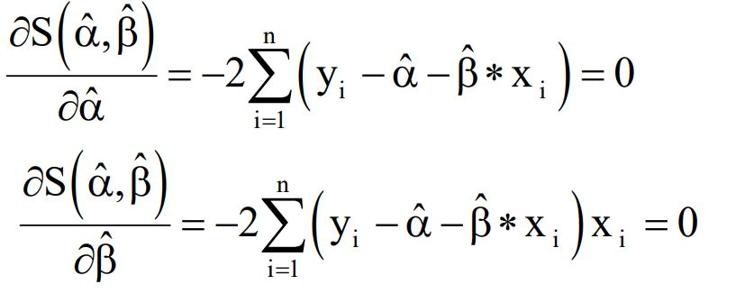

#### ==> This is just a linear system of two equations with two unknowns alpha and beta, which we can mathematically solve for alpha.

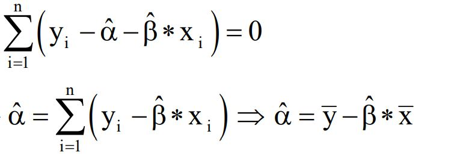

#### and for beta

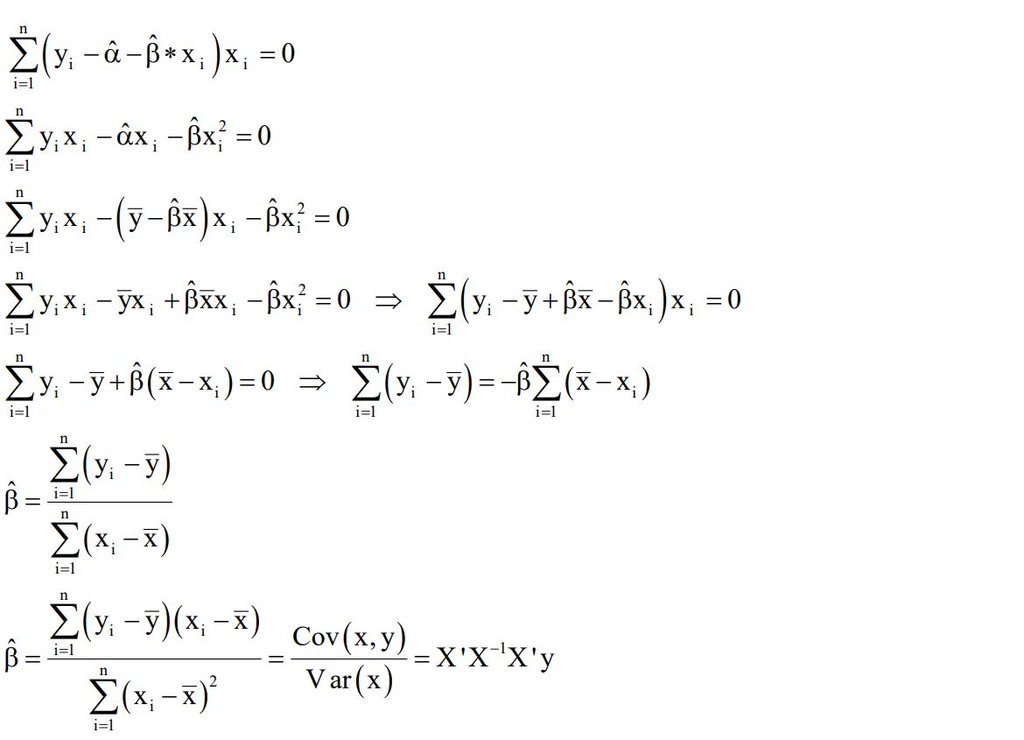

#### If we write interms of m = slop & b = Y_intercept

==> Beta equals the covariance between y and x divided by the variance of x.

**Interpretation: example**

• alpha=4.97, beta=1.06

• Education and earnings: no education gives you a minimal hourly wage of around 5 pounds. Each additional year of education increases the hourly wage by app. 1 pound:

### Steps to solve manually Simple linear regression

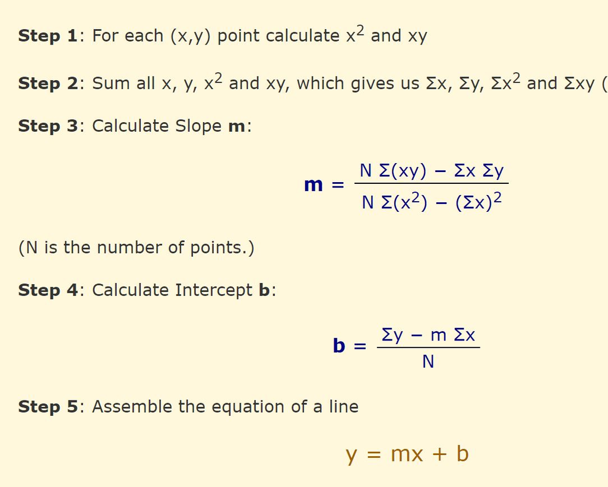

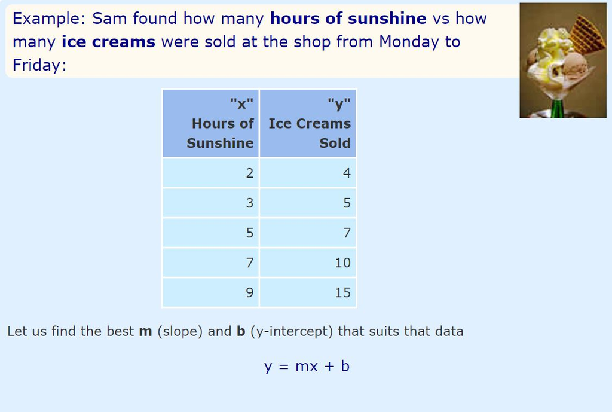

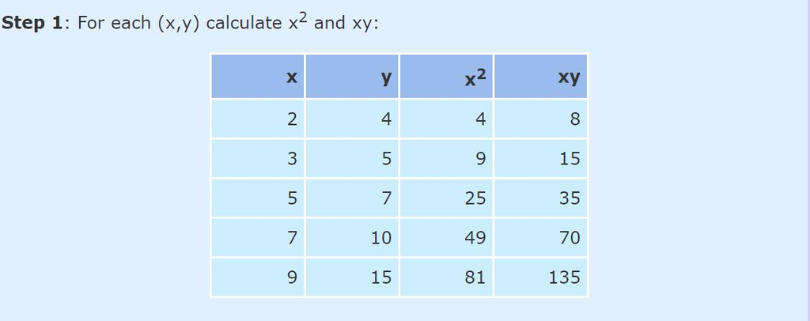

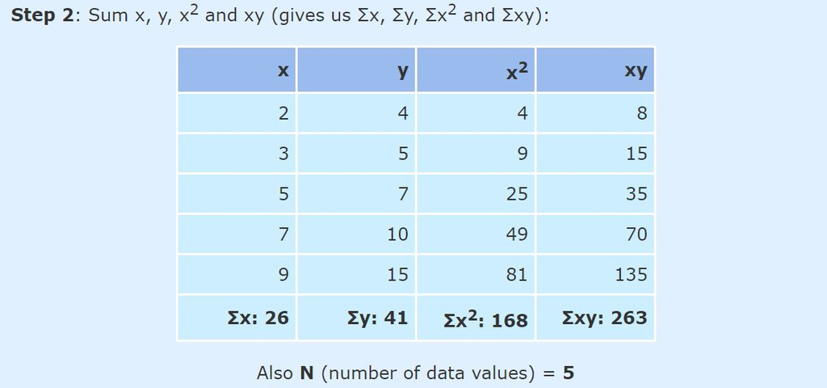

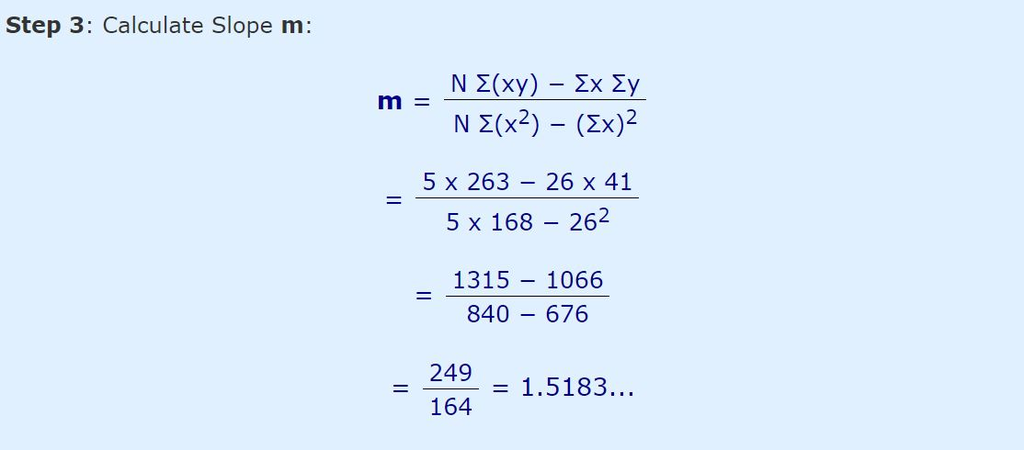

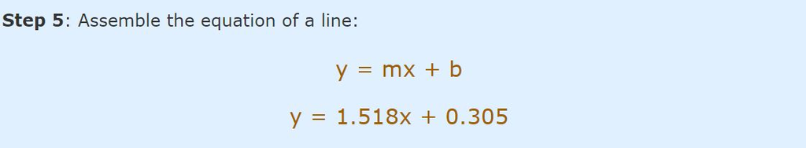

==> Now, the Error(Residuals)

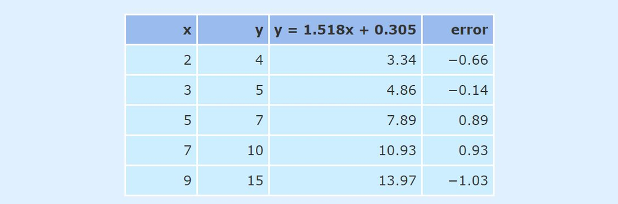

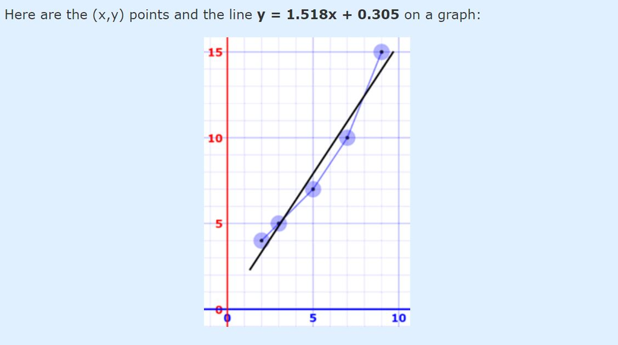

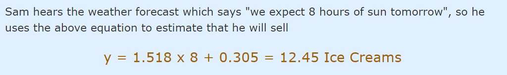

## Example : 1

#### Lets take above example

```python
import numpy as np
```

```python
x = [2,3,5,7,9]
y = [4,5,7,10,15]
```

```python
sigma_x = np.sum(x)
print(sigma_x)
sigma_x_square = np.square(sigma_x)
print(sigma_x_square)
sigma_y = np.sum(y)
print(sigma_y)
```

```
26
676
41
```

```python
XY = np.matmul(x,y)
sigma_XY = np.sum(XY)
print(sigma_XY)
```

```
263
```

```python
XSQUARE = np.square(x)
sigma_xsquare = np.sum(XSQUARE)
print(sigma_xsquare)
```

```
168
```

```python
N = len(x)
print(N)
```

```
5
```

```python
m = (N * sigma_XY - sigma_x * sigma_y) / (N * sigma_xsquare - sigma_x_square)
```

```python
m
```

```
1.5182926829268293
```

```python
c = (sigma_y - m * sigma_x) / N
```

```python
c
```

```
0.30487804878048763
```

```python
print(f'The equation is: y = {c:.4f} + {m:.4f} x')
```

```
The equation is: y = 0.3049 + 1.5183 x
```

```python
#for making new prediction
# lets take new value x = 10
y = 0.3049 + 1.5183 * 10
```

```python
y
```

```
15.4879
```

## Example : 2

```python
import numpy as np
import matplotlib.pyplot as plt
```

```python
data=np.loadtxt("Q1.txt",skiprows=1,dtype=float)
```

```python
y = [data[i][0] for i in range (len(data))]
# print(y)
x = [data[j][1] for j in range (len(data))]
# print(x)
```

```python
sigma_x = np.sum(x)
print(sigma_x)
sigma_y = np.sum(y)
print(sigma_y)
```

```
16163.0
3641.0
```

```python
XY = np.matmul(x,y)
print(np.sum(XY))
```

```
2334653.0
```

```python
XSQUARE = np.square(x)
sigma_xsquare = np.sum(XSQUARE)
print(sigma_xsquare)
```

```
10195199.0
```

```python
N = len(x)
```

```python
a = np.matrix([[N,sigma_x],[sigma_x,sigma_xsquare]])
b = np.array([sigma_y,XY])
```

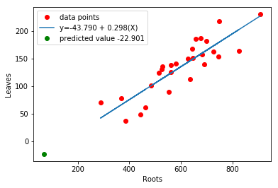

```python
equation = np.linalg.solve(a,b)
# print(equation)

plt.plot(x,y,"ro",label="data points")

y_new = equation[0]+np.multiply(equation[1],x)
# print(y)

plt.plot(x,y_new,label="y=%0.3f + %0.3f(X)"%(equation[0],equation[1]))
# print("predicted values for roots is ",equation[0]+equation[1]*70)

plt.plot(70,equation[0]+equation[1]*70,"go",label="predicted value %0.3f"%(equation[0]+equation[1]*70))
plt.xlabel("Roots")

plt.ylabel("Leaves")
plt.legend()

# print("y bar is equal to",sigma_y/N)
# print("a+bx is equal to ",equation[0]+equation[1]*(sigma_x/N))

plt.show()
```

## Example : 3

```python
import numpy as np
import matplotlib.pyplot as plt
import math
```

```python
x = [float(x) for x in range(0,6,1)]
print("X => ",x)
y = [float(y) for y in [5,6,9,12,13,16]]
print("Y => ",y)
```

```
X =>  [0.0, 1.0, 2.0, 3.0, 4.0, 5.0]
Y =>  [5.0, 6.0, 9.0, 12.0, 13.0, 16.0]
```

```python
N = len(x)
print("Total data points :- ",N)
```

```
Total data points :-  6
```

```python
sigma_x = np.sum(x)
print("Sigma x :- ",sigma_x)
```

```
Sigma x :-  15.0
```

```python
sigma_y = np.sum(y)
print("Sigma y :- ",sigma_y)
```

```
Sigma y :-  61.0
```

```python
xi_yi =[x*y for x,y in zip(x,y)]
print("xi*yi :- ",xi_yi)
```

```
xi*yi :-  [0.0, 6.0, 18.0, 36.0, 52.0, 80.0]
```

```python
sigma_xi_yi = np.sum(xi_yi)
print("Sigma xi*yi :- ",sigma_xi_yi)
```

```
Sigma xi*yi :-  192.0
```

```python
xi_list_squre = [i**2 for i in x]
print("Sigma xi_squre :- ",xi_list_squre)

xi_squre=(np.sum(xi_list_squre))
```

```
Sigma xi_squre :-  [0.0, 1.0, 4.0, 9.0, 16.0, 25.0]
```

```python
# https://courses.lumenlearning.com/ivytech-collegealgebra/chapter/using-cramers-rule-to-solve-a-system-of-two-equations-in-two-variables/
Dx = np.matrix([[sigma_y,sigma_x],[sigma_xi_yi,xi_squre]])
Dy = np.matrix([[N,sigma_y],[sigma_x,sigma_xi_yi]])
D = np.matrix([[N,sigma_x],[sigma_x,xi_squre]])
```

```python
a = np.linalg.det(Dx) / np.linalg.det(D)
b = np.linalg.det(Dy) / np.linalg.det(D)
print("intercept :- ",a)
print("slop :- ",b)
```

```
intercept :-  4.5238095238095175
slop :-  2.2571428571428567
```

```python
best_fit_line = [(b*x)+a for x in x]
```

```python
best_fit_line = []
for i in x:
    best_fit_line.append((b*i)+a)
```

```
[4.5238095238095175, 6.780952380952375, 9.03809523809523, 11.295238095238087, 13.552380952380943, 15.8095238095238]
```

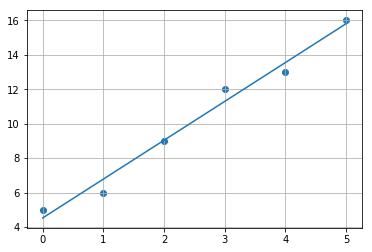

```python
print(best_fit_line)
plt.scatter(x,y)
plt.plot(x, best_fit_line)
plt.grid()
plt.show()
```

## Example : 4

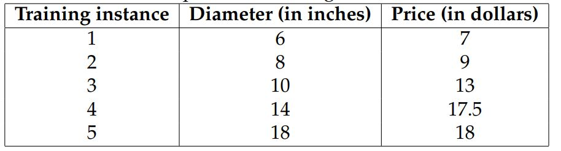

```python
from sklearn.linear_model import LinearRegression
import numpy as np
```

```python
# Training data
X = np.array([6, 8, 10, 14, 18]).reshape(-1, 1)
y = [7, 9, 13, 17.5, 18]
# y = [[7], [9], [13], [17.5], [18]]
```

```python
#Create and fit the model
model = LinearRegression()

model.fit(X, y)

m=model.coef_[0]

c=model.intercept_
```

```python
print(f'Slope = {m:.4f}, Intercept = {c:.4f}')
print(f'The equation is: y = {c:.4f} + {m:.4f} x')
print(f'A 12" pizza should cost y = {c:.4f} + {m:.4f} *12')
print(f'A 12" pizza should cost y = ', m * 12 + c)
```

```
Slope = 0.9763, Intercept = 1.9655
The equation is: y = 1.9655 + 0.9763 x
A 12" pizza should cost y = 1.9655 + 0.9763 *12
A 12" pizza should cost y =  13.681034482758621
```

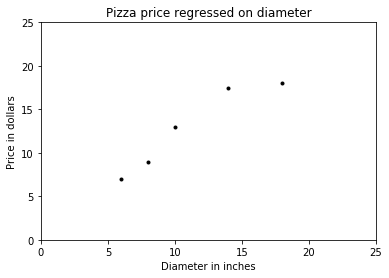

```python
import matplotlib.pyplot as plt
plt.figure(1)
plt.title('Pizza price regressed on diameter')
plt.xlabel('Diameter in inches')
plt.ylabel('Price in dollars')
plt.axis([0, 25, 0, 25])
plt.plot(X, y, 'k.')
#plt.scatter(X,y,color='black')
plt.show()
```

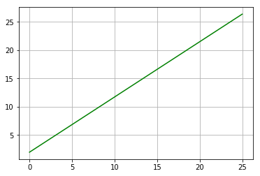

```python
X2 = [[0], [10], [14], [25]]
y2 = model.predict(X2)
plt.figure(1)
plt.grid(True)
plt.plot(X2, y2, 'g-')
plt.show()
```

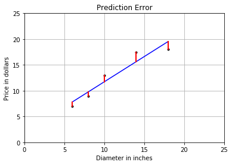

```python
# prediction errors or test errors.
plt.figure(2)
plt.title('Prediction Error')
plt.xlabel('Diameter in inches')
plt.ylabel('Price in dollars')
plt.axis([0, 25, 0, 25])
plt.grid(True)
y_predict = model.predict(X)
plt.plot(X, y, 'k.', X, y_predict, 'b-')
# plt.plot([6, 6], [7, 7.823275862068968], color='b', linestyle='-', linewidth=2)
for ix in range(len(X)):
    plt.plot([X[ix], X[ix]],[y[ix], y_predict[ix]],color='r', linestyle='-', linewidth=2)
plt.show()
```

## Example : 5

```python
import numpy as np
import tensorflow as tf
import matplotlib.pyplot as plt
```

```python
np.random.seed(101)
tf.set_random_seed(101)
```

==> Genrating random linear data

==> There will be 50 data points ranging from 0 to 50

```python
x = np.linspace(0, 50, 50)
y = np.linspace(0, 50, 50)
```

==> Adding noise to the random linear data

```python
x += np.random.uniform(-4, 4, 50)
y += np.random.uniform(-4, 4, 50)

n = len(x) # Number of data points
```

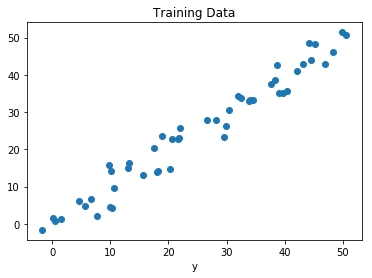

```python
# Plot of Training Data
plt.scatter(x, y)
plt.xlabel('x')
plt.xlabel('y')
plt.title("Training Data")
plt.show()
```

```python
X = tf.placeholder("float")
Y = tf.placeholder("float")
```

```python
W = tf.Variable(np.random.randn(), name = "W")
b = tf.Variable(np.random.randn(), name = "b")
```

```python
learning_rate = 0.01
training_epochs = 1000
```

```python
# Hypothesis
y_pred = tf.add(tf.multiply(X, W), b)

# Mean Squared Error Cost Function
cost = tf.reduce_sum(tf.pow(y_pred-Y, 2)) / (2 * n)

# Gradient Descent Optimizer
optimizer = tf.train.GradientDescentOptimizer(learning_rate).minimize(cost)

# Global Variables Initializer
init = tf.global_variables_initializer()
```

```
WARNING:tensorflow:From C:\ProgramData\Anaconda3\lib\site-packages\tensorflow\python\ops\math_grad.py:1205: add_dispatch_support.<locals>.wrapper (from tensorflow.python.ops.array_ops) is deprecated and will be removed in a future version.
Instructions for updating:
Use tf.where in 2.0, which has the same broadcast rule as np.where
```

```python
# Starting the Tensorflow Session
with tf.Session() as sess:

	# Initializing the Variables
	sess.run(init)

	# Iterating through all the epochs
	for epoch in range(training_epochs):

		# Feeding each data point into the optimizer using Feed Dictionary
		for (_x, _y) in zip(x, y):
			sess.run(optimizer, feed_dict = {X : _x, Y : _y})

		# Displaying the result after every 50 epochs
		if (epoch + 1) % 50 == 0:
			# Calculating the cost a every epoch
			c = sess.run(cost, feed_dict = {X : x, Y : y})
			print("Epoch", (epoch + 1), ": cost =", c, "W =", sess.run(W), "b =", sess.run(b))

	# Storing necessary values to be used outside the Session
	training_cost = sess.run(cost, feed_dict ={X: x, Y: y})
	weight = sess.run(W)
	bias = sess.run(b)
```

```
Epoch 50 : cost = 5.8868036 W = 0.9951241 b = 1.238105
Epoch 100 : cost = 5.79127 W = 0.99812365 b = 1.0914395
Epoch 150 : cost = 5.7119684 W = 1.0008028 b = 0.96044284
Epoch 200 : cost = 5.6459413 W = 1.0031956 b = 0.84343934
Epoch 250 : cost = 5.5907993 W = 1.0053328 b = 0.7389355
Epoch 300 : cost = 5.544608 W = 1.007242 b = 0.6455921
Epoch 350 : cost = 5.5057893 W = 1.008947 b = 0.56221986
Epoch 400 : cost = 5.473066 W = 1.01047 b = 0.48775342
Epoch 450 : cost = 5.445385 W = 1.0118302 b = 0.42124158
Epoch 500 : cost = 5.4219036 W = 1.0130452 b = 0.36183482
Epoch 550 : cost = 5.4019227 W = 1.0141305 b = 0.30877408
Epoch 600 : cost = 5.3848557 W = 1.0150996 b = 0.2613811
Epoch 650 : cost = 5.370246 W = 1.0159653 b = 0.21905078
Epoch 700 : cost = 5.3576994 W = 1.0167387 b = 0.18124203
Epoch 750 : cost = 5.3468933 W = 1.0174294 b = 0.14747237
Epoch 800 : cost = 5.337558 W = 1.0180461 b = 0.11730931
Epoch 850 : cost = 5.3294754 W = 1.0185971 b = 0.090368524
Epoch 900 : cost = 5.322459 W = 1.0190892 b = 0.06630575
Epoch 950 : cost = 5.3163586 W = 1.0195289 b = 0.044813294
Epoch 1000 : cost = 5.3110332 W = 1.0199214 b = 0.02561658
```

```python
# Calculating the predictions
predictions = weight * x + bias
print("Training cost =", training_cost, "Weight =", weight, "bias =", bias, '\n')
```

```
Training cost = 5.3110332 Weight = 1.0199214 bias = 0.02561658
```

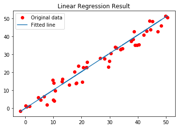

```python
# Plotting the Results
plt.plot(x, y, 'ro', label ='Original data')
plt.plot(x, predictions, label ='Fitted line')
plt.title('Linear Regression Result')
plt.legend()
plt.show()
```

#### RAJKUMAR ZALAVADIA - Mo: 7041645834 Email : rajzalavadia50@gmail.com